# Progress report 2

# Distribution of raw reads

## Barplots

**Grouped by Sex variable**

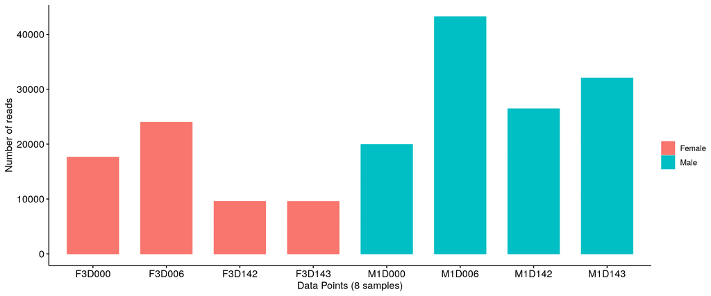

```r
library(ggpubr)

readbar1 <- ggbarplot(f_readcount.v.m, x = "SampleID", y = "value",
          fill = "Sex",           # change fill color by mpg_level
          color = "Sex",            # Set bar border colors to white
          palette = "rainbow",            # jco journal color palett. see ?ggpar
          # sort.val = "desc",           # Sort the value in ascending order
          sort.by.groups = TRUE,     # Don't sort inside each group
          x.text.angle = 0,          # Rotate vertically x axis texts
          ylab = "Number of reads",
          xlab = "Data Points (8 samples)",
          legend.title = ""
          ) #+ noxlabels

ggpubr::ggarrange(readbar1, ncol = 1, nrow = 1,  common.legend = TRUE, legend = "right", align = "hv", labels = "")
```

Figure x: Barplots of pre-processed reads grouped by sex variable.

**Grouped by Time variable**

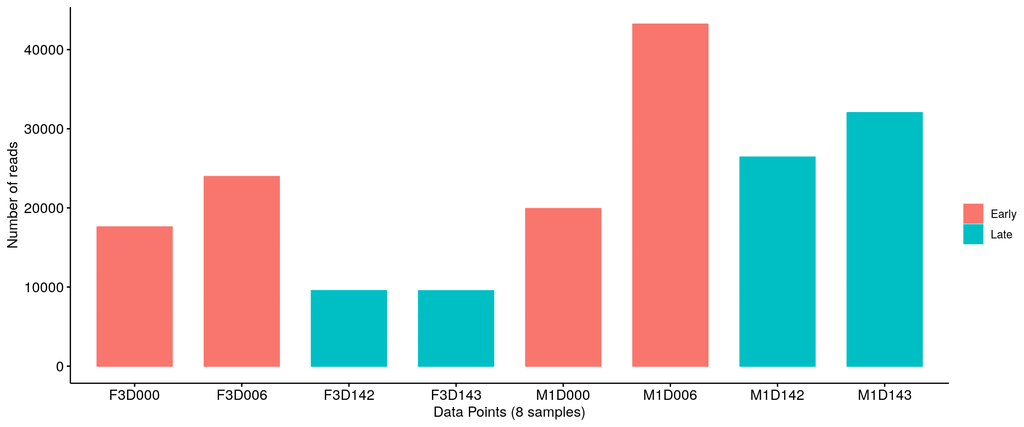

```r
library(ggpubr)

readbar2 <- ggbarplot(f_readcount.v.m, x = "SampleID", y = "value",
          fill = "Time",           # change fill color by mpg_level
          color = "Time",            # Set bar border colors to white
          palette = "rainbow",            # jco journal color palett. see ?ggpar
          # sort.val = "desc",           # Sort the value in ascending order
          sort.by.groups = TRUE,     # Don't sort inside each group
          x.text.angle = 0,          # Rotate vertically x axis texts
          ylab = "Number of reads",
          xlab = "Data Points (8 samples)",
          legend.title = ""
          ) #+ noxlabels

ggpubr::ggarrange(readbar2, ncol = 1, nrow = 1,  common.legend = TRUE, legend = "right", align = "hv", labels = "")
```

Figure x: Barplots of pre-processed reads grouped by time variable

**Grouped by days-post-weaning (D) variable**

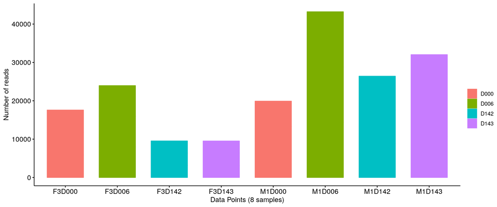

```r
library(ggpubr)

readbar3 <- ggbarplot(f_readcount.v.m, x = "SampleID", y = "value",
          fill = "DayID",           # change fill color by mpg_level
          color = "DayID",            # Set bar border colors to white
          palette = "rainbow",            # jco journal color palett. see ?ggpar
          # sort.val = "desc",           # Sort the value in ascending order
          sort.by.groups = TRUE,     # Don't sort inside each group
          x.text.angle = 0,          # Rotate vertically x axis texts
          ylab = "Number of reads",
          xlab = "Data Points (8 samples)",
          legend.title = ""
          ) #+ noxlabels

ggpubr::ggarrange(readbar3, ncol = 1, nrow = 1,  common.legend = TRUE, legend = "right", align = "hv", labels = "")
```

# Base call quality

- In the results folder you will find a folder named *multiqc* which contains data for HTML display. Right-click-open with your favorite browser
- Using CLI: Alternatively, open the HTML file on command line by running the following commands

## Original base call quality (qc0)

```
open ./results/multiqc/qc0/multiqc_report.html
open ./results/multiqc/qc0/R1/multiqc_report.html
open ./results/multiqc/qc0/R2/multiqc_report.html
```

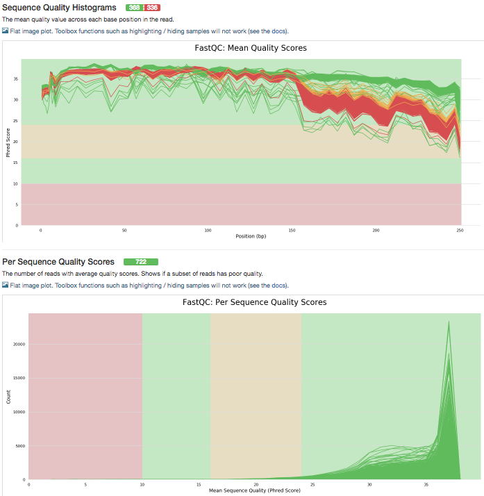

Figure x: Example of report generated by running **open ./results/multiqc/qc0/multiqc_report.html** on CLI

## Base call quality after trimming at Q = 25 (qctrim25)

```
open ./results/multiqc/qctrim25/multiqc_report.html
open ./results/multiqc/qctrim25/R1/multiqc_report.html
open ./results/multiqc/qctrim25/R2/multiqc_report.html
```

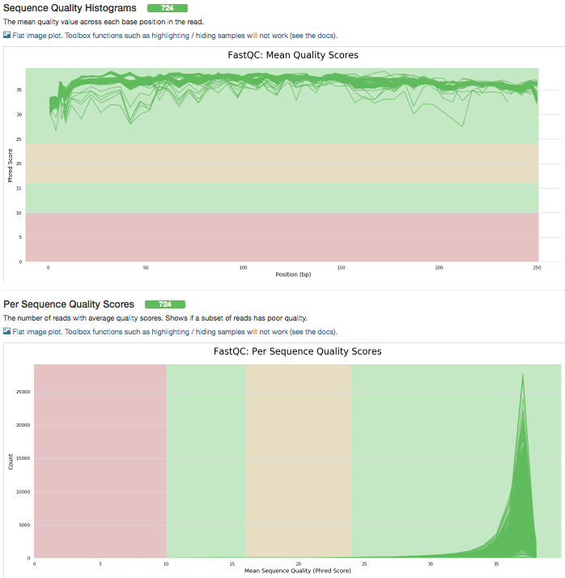

## Base call quality after removing phiX

```
open ./results/multiqc/qced/multiqc_report.html
open ./results/multiqc/qced/R1/multiqc_report.html
open ./results/multiqc/qced/R2/multiqc_report.html
```

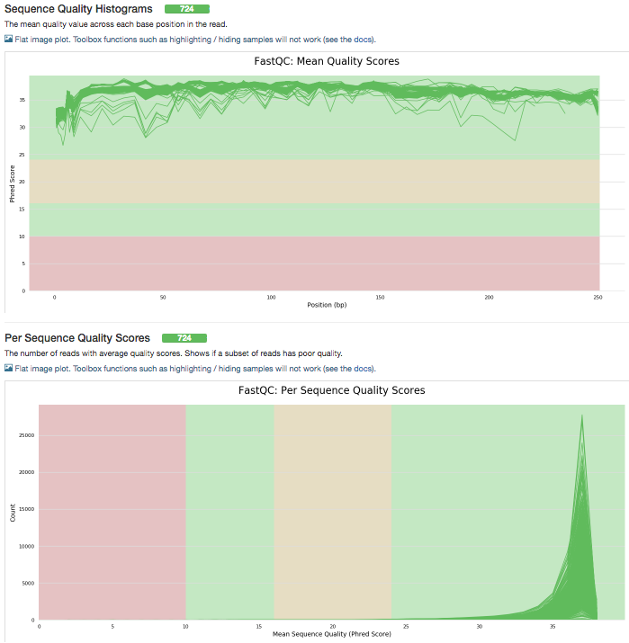